# Week 4 — RNA-seq

Author

Abby Farr

Published

October 29, 2026

## 1. This week’s analysis

Load in packages

```r
#install.packages("BiocManager")
#BiocManager::install("DESeq2")
library(DESeq2)
```

Load Reads

```r
counts_url <- "https://raw.githubusercontent.com/RobertsLab/paper-tanner-crab/master/analyses/kallisto-0812/kallisto-0812.isoform.counts.matrix"
counts <- read.delim(counts_url, row.names = 1, check.names = FALSE)

# kallisto gives estimated counts with decimals; DESeq2 needs whole numbers
counts <- round(counts)

dim(counts)   # 78,649 transcripts x 4 samples
```

```
[1] 78649     4
```

```r
head(counts)
```

```
                         380822_cold_uninfected 380823_cold_infected
TRINITY_DN9654_c0_g1_i1                     269                  195
TRINITY_DN2423_c0_g1_i5                      70                   55
TRINITY_DN35884_c0_g1_i1                     17                   11
TRINITY_DN51908_c0_g1_i1                      3                    4
TRINITY_DN10230_c0_g1_i5                      0                    0
TRINITY_DN556_c1_g1_i4                        0                   24
                         380824_warm_uninfected 380825_warm_infected
TRINITY_DN9654_c0_g1_i1                     271                  245
TRINITY_DN2423_c0_g1_i5                     113                  103
TRINITY_DN35884_c0_g1_i1                     12                    9
TRINITY_DN51908_c0_g1_i1                      7                    4
TRINITY_DN10230_c0_g1_i5                      0                    0
TRINITY_DN556_c1_g1_i4                       30                   10
```

> Reads are divided into four different catagories, cold_uninfected, cold_infected, warm_uninfected, and warm_infected with counts of how many counts are in each category at each site.

Describe sample Each row of the metadata describes one column of the count matrix, in the same order.

```r
coldata <- data.frame(
  row.names   = colnames(counts),
  infection   = factor(c("uninfected", "infected", "uninfected", "infected")),
  temperature = factor(c("cold", "cold", "warm", "warm"))
)
coldata
```

```
                        infection temperature
380822_cold_uninfected uninfected        cold
380823_cold_infected     infected        cold
380824_warm_uninfected uninfected        warm
380825_warm_infected     infected        warm
```

```r
# Stop here if the names don't line up
stopifnot(all(rownames(coldata) == colnames(counts)))
```

> create count matrix

Build the DESeq2 object

```r
dds <- DESeqDataSetFromMatrix(countData = counts,
                              colData   = coldata,
                              design    = ~ infection)
# Levels are alphabetical by default, so "infected" would be the reference.
# Make "uninfected" the baseline so a positive log2FoldChange means higher in infected crabs.
dds$infection <- relevel(dds$infection, ref = "uninfected")

# Drop transcripts with almost no reads
dds <- dds[rowSums(counts(dds)) >= 10, ]
nrow(dds)
```

```
[1] 38411
```

> Number of counts left after removing counts with less than 10 reads

Check sample structure Do this before testing anything. Do the samples group by infection, by temperature, or by neither?

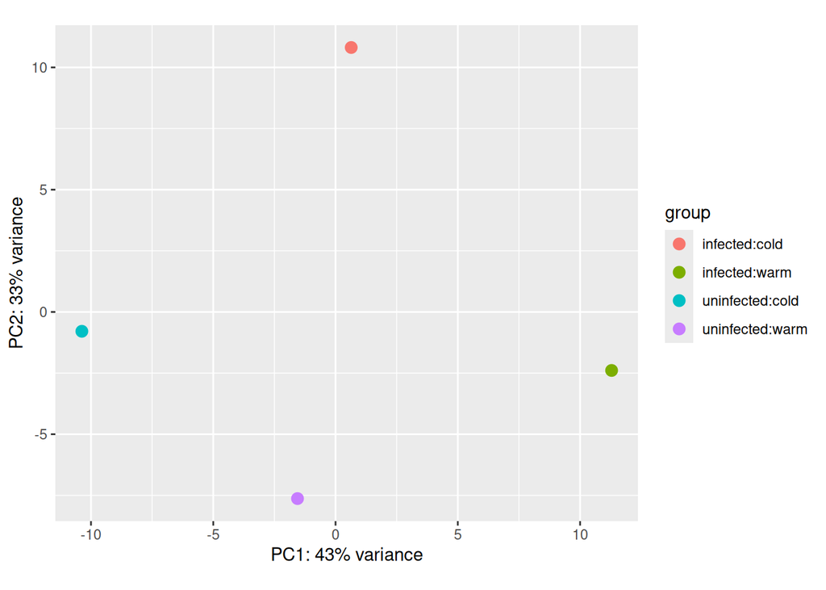

```r
vsd <- vst(dds, blind = TRUE)
plotPCA(vsd, intgroup = c("infection", "temperature"))
```

> Infected_cold is further away from the other three categories on PC2 meaning it is more different from the rest of the counts in the category and uninfected war and infected cold oare closer on PC1 than the other two indicating that reads in those categories are more similar.

Test for differential expression

```r
dds <- DESeq(dds)
res <- results(dds, alpha = 0.05)

summary(res)
```

```
out of 38411 with nonzero total read count
adjusted p-value < 0.05
LFC > 0 (up)       : 1050, 2.7%
LFC < 0 (down)     : 116, 0.3%
outliers [1]       : 0, 0%
low counts [2]     : 17872, 47%
(mean count < 11)
[1] see 'cooksCutoff' argument of ?results
[2] see 'independentFiltering' argument of ?results
```

```r
sum(res$padj < 0.05, na.rm = TRUE)   # number of significant transcripts
```

```
[1] 1166
```

PLot and save results

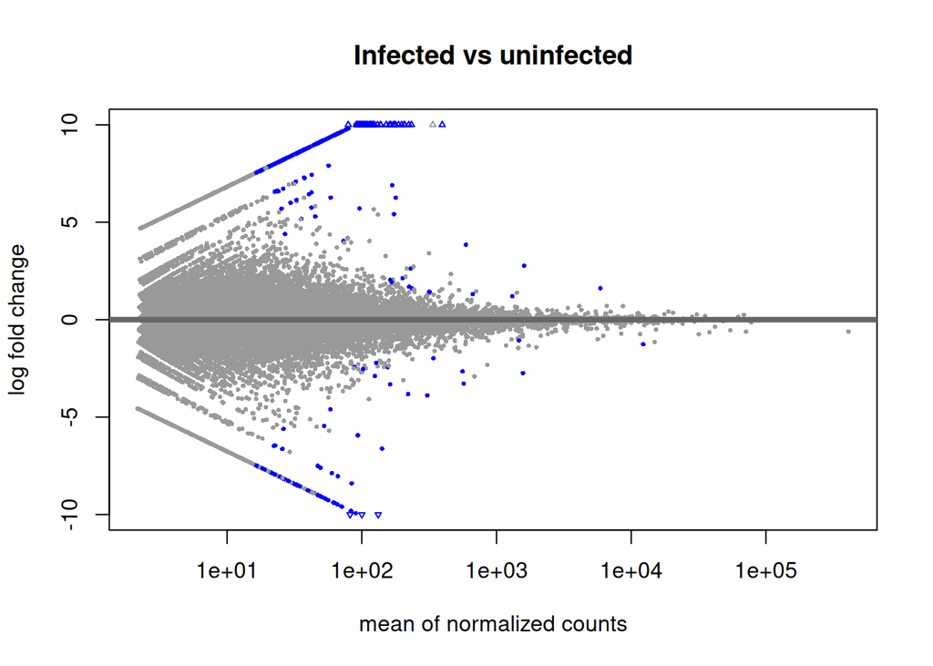

```r
plotMA(res, ylim = c(-10, 10), main = "Infected vs uninfected")
```

```r
res_df <- as.data.frame(res)
res_df$transcript_id <- rownames(res_df)
res_df <- res_df[order(res_df$padj), ]
head(res_df)
```

```
                           baseMean log2FoldChange     lfcSE      stat
TRINITY_DN6598_c0_g1_i1   592.21994       3.850404 0.3651638 10.544319
TRINITY_DN8711_c0_g1_i18  100.14287     -22.912697 2.8099507 -8.154128
TRINITY_DN303_c1_g1_i6     97.63447      22.827791 2.7861184  8.193403
TRINITY_DN2290_c3_g2_i8    81.81434     -23.223401 2.8706157 -8.090042
TRINITY_DN43504_c0_g1_i19  79.28553      22.537883 2.8490779  7.910588
TRINITY_DN2394_c1_g1_i12  395.39675      12.128579 1.5534399  7.807562
                                pvalue         padj             transcript_id
TRINITY_DN6598_c0_g1_i1   5.396232e-26 1.108332e-21   TRINITY_DN6598_c0_g1_i1
TRINITY_DN8711_c0_g1_i18  3.517087e-16 2.407915e-12  TRINITY_DN8711_c0_g1_i18
TRINITY_DN303_c1_g1_i6    2.539418e-16 2.407915e-12    TRINITY_DN303_c1_g1_i6
TRINITY_DN2290_c3_g2_i8   5.964431e-16 3.062586e-12   TRINITY_DN2290_c3_g2_i8
TRINITY_DN43504_c0_g1_i19 2.561752e-15 1.052316e-11 TRINITY_DN43504_c0_g1_i19
TRINITY_DN2394_c1_g1_i12  5.830458e-15 1.995863e-11  TRINITY_DN2394_c1_g1_i12
```

```r
dir.create("output/week04", recursive = TRUE, showWarnings = FALSE)
write.csv(res_df, "output/week04/dge-results.csv", row.names = FALSE)
```

> postive log fold change means there are higher reads for infected crabs and a negative log fold change means there are higher reads for uninfectd crabs.

Write a caveats paragraph about design, sample size, and biological interpretation.

> Some caveats to this is that in a sample site you are more likely to get crabs in the same category than in both categories. Crabs live in close proximity to each other so and infected crab is more likey to get crabs in the vacinity infected. Another cavaet is that there were only four sites samples so it is hard to tell if there was a wide variety of crabs sampled.

## 2. Reflection questions

1. Why is sample metadata as important as the count matrix?

> Count matrix tells us what we need to know about the read, like what type of read it is (ex:RNA or eDNA) along with how mny sequences are in that read for that category. The sample matrix is just as important because it provides context for where these reads come from and why they could be useful.
2. What is the difference between statistical significance and biological importance in differential expression?

> Statistical significance is how likel you are to detect a true alternative to the null and is based on statistical equations whereas biological importance tells us what is happening in the environment.
3. If your project is not RNA-seq, what is the equivalent of a count matrix and a results table in your workflow?

> I am using eDNA so the equivalent of a count matrix would be a count matrix would be the number of reads per site and a result table would be how many of each species were at that site.

## 3. Project progress

> This week I was able to cleaning up reads and creating a visual for them.

## 4. Where I’m stuck

> none

## 5. Next week

> Next week I want to download the reference data and then assign taxonomy.